# Researching and Writing the Literature Review

GE2021 Research Technology, Fall 2026

Chad (Chungil Chae)

cchae@kean.edu

Tue, 15 September 2026

# Learning Objectives(Pajo, 2022)

1. Describe the purpose of a literature review
2. Learn about online databases as resources
3. Examine different ways of organizing a literature review
4. Discuss how to think critically and analyze studies
5. Identify the correct placement of study hypotheses
6. Compare and contrast a systematic review of the literature and a literature review

## SHORT VIDEO INTRODUCTION

[video not shown]

# Defining a Literature Review

## Literature Review and Its Purpose

- Literature review: the synthesis of the entire body of all the original research studies in a specific topic of interest; not just reporting them but engaging, discussing, and synthesizing the body of work in its entirety.
- Its purpose is to demonstrate the researcher’s grasp on the topic of interest and to support their argument for the necessity of the proposed study

## Literature Review as Research Method

### The Importance of Literature Reviews

- knowledge production in many fields (such as business research) is **growing quickly** and becoming ever more interdisciplinary, making it challenging to remain current (Snyder, 2019).
- Literature reviews play a critical role in synthesizing existing knowledge so researchers can identify the state of the art, pinpoint **research gaps**, and **generate research questions**.

### Three Broad Approaches to Literature Reviews

- **Systematic Reviews:** A method originating in medical science, designed to locate, appraise, and synthesize all empirical evidence relevant to a clearly formulated question.
  - Highly structured and transparent (e.g., PRISMA guidelines).
  - Often relies on statistical methods (like meta-analysis) to combine findings from different studies.
  - Suitable when the research question is specific (e.g., “What is the effect of factor X on Y?”).
  - Rigor and replicability: clearly documented steps and inclusion/exclusion criteria. Can inform evidence-based practice or policy by summarizing overall effects.
- **Semi-Systematic (or Narrative) Reviews:** Useful when a topic has been studied across diverse disciplines under various conceptualizations, making a fully systematic approach difficult.
  - Often broader in scope than systematic reviews. May use qualitative and/or quantitative methods to map themes, theoretical perspectives, or historical trends.
  - Can capture a wide variety of theoretical perspectives. Good for identifying knowledge gaps or mapping how research on a topic has developed over time.
- **Integrative Reviews:** Aims to critically review, synthesize, and “integrate” literature on a topic in order to advance theoretical frameworks or create new conceptual models.
  - Often used for mature or emerging topics. Requires careful selection of literature and a high level of conceptual thinking. More flexible but must still be transparent about methods.
  - Can lead to significant theoretical contributions by reconceptualizing or building new frameworks.

### The Review Process: Four Phases

- **Designing the Review:** *Articulate why the review is needed.*
  - Develop a clear research question aligned with the purpose of the review.
  - Select an appropriate approach (systematic, semi-systematic, or integrative).
  - Determine search strategy, databases, and inclusion/exclusion criteria.
- **Conducting the Review:** *Pilot-test the search terms and inclusion criteria.*
  - Screen articles (e.g., by title, abstract, full text) to arrive at the final sample.
  - Document decisions throughout to ensure transparency.
- **Analysis:** *Extract relevant data and code it systematically*
  - e.g., study characteristics, results, theoretical perspectives
  - Use an analysis method that fits your review approach (e.g., meta-analysis, thematic analysis).
- **Writing Up the Review:** *Clearly present methods so readers can assess trustworthiness.*
  - Organize findings coherently (e.g., by themes, chronological development, or theoretical frameworks).
  - Highlight contributions, implications, limitations, and future research directions.

### Evaluating a Literature Review

> The author stresses the importance of transparency, depth, rigor, and usefulness.

A well-executed review should:

- **Clearly define its purpose and scope**.
- **Explain and justify the methodology**.
- **Demonstrate that the chosen method and inclusion criteria were appropriate for the research question**.
- **Make a meaningful contribution**
  - e.g., identifying research gaps, providing theoretical or practical insights, introducing a conceptual model

### Common Pitfalls

- Failing to describe the review’s methodology in detail
  - e.g., insufficient information about how articles were chosen
- Restricting the search scope too narrowly
  - e.g., only certain journals or brief time spans) without a clear rationale
- Offering only descriptive findings
  - e.g., listing how many articles there are on a topic) without deeper analysis
- Not translating the findings into a valuable contribution
  - e.g., new theory, framework, or clear research agenda

### Discussion Points

- **Purpose and Value of Literature Reviews**
  - Why are literature reviews a cornerstone of rigorous academic research?
  - How do they help researchers avoid “reinventing the wheel”?
- **Choosing the Right Approach**
  - Under which circumstances might a systematic review be most suitable?
  - When might a semi-systematic or an integrative review be preferable?
- **Ensuring Rigor and Transparency**
  - What are the consequences of non-transparency (e.g., failing to detail how you selected articles)?
  - Why is it essential for other scholars to replicate or verify your review method?
- **Quality vs. Quantity**
  - How do inclusion and exclusion criteria affect the results of a review?
  - Why is it better to refine the research question carefully rather than arbitrarily exclude large sets of studies?
- **Making a Theoretical Contribution**
  - How can a literature review go beyond summarizing existing work and actually build or refine theory?
  - In what ways can a review pave the way for new empirical research?
- **Ethical Dimensions**
  - How might bias (intentional or unintentional) creep into the selection or interpretation of studies?
  - What steps can researchers take to mitigate bias?

### Summary

- Literature reviews are a rigorous research methodology that requires clear purpose, methodical searching, transparent selection criteria, and an appropriate analysis technique.
- Researchers can adopt systematic, semi-systematic, or integrative reviews based on their specific goals—e.g., evidence of effect, mapping of themes, or building new theory.
- Thorough documentation, transparency, and a strong conceptual or theoretical contribution can make a review more likely to be useful, impactful, and publishable.

# Exploring the Literature

## Using Libraries and Online Databases

- Access online databases through a library’s website
- Schools often have librarians for specific fields to help navigate databases in a specific area of inquiry.

## Using Search Engines

- Most databases have similar search engines that are easy to navigate
- Use “advanced search” rather than quick searches
- Boolean operators: using AND, OR, NOT to combine keywords in searching

## Using Interlibrary Loan

- Interlibrary loan: the ability to access inventory of books and articles available in a library other than your own.
- WKU Interlibrary Loan
  - https://library.wku.edu.cn/en/interlibrary-loan-request-form

[figure not shown]

## Writing Annotated Bibliographies

- Annotated bibliography: a brief summary of the article or book read, including explanations and comments on the citations.

# Understanding and Organizing the Literature

## Creating a Guiding Table

- Creating a table helps to understand the studies better and grasp what information needs to go into the literature review.
- Assigning each study an ID number can help organize them and can be the first column of the table.
- Other columns include author names, publication and study dates, locations, theories used, information on the participants, and so on.

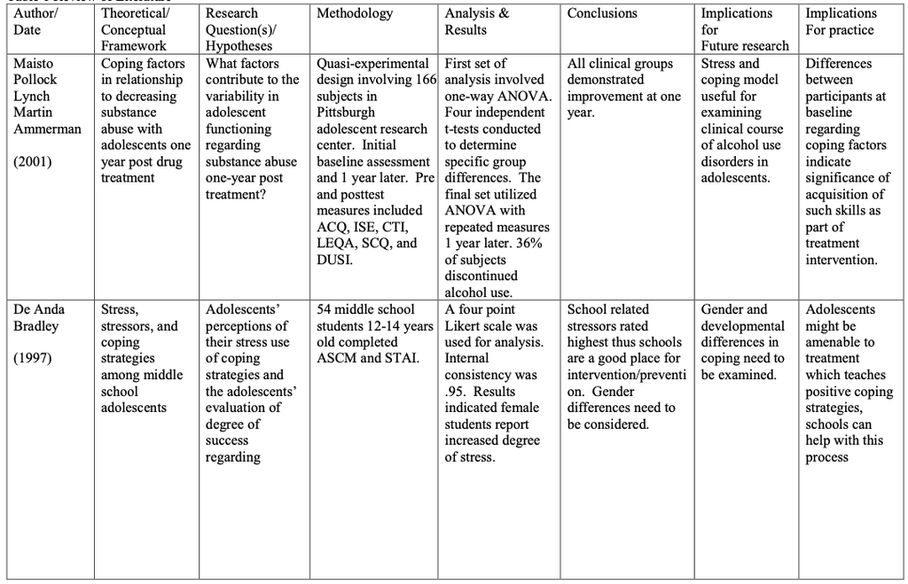

## Using the Conceptual Graph

- Reviewing the literature can cause adjustments to be made on the conceptual graph of constructs and variables.

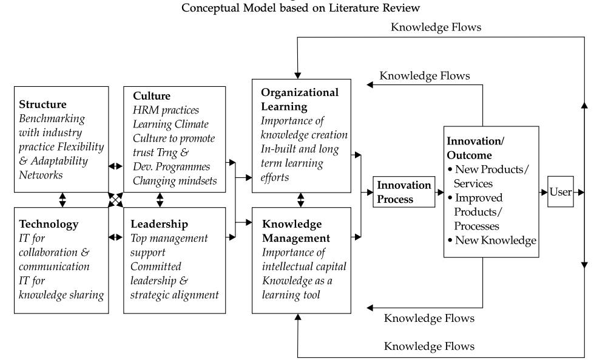

## Organizing Your Work

- Researchers have their own styles of organizing literature.
- No matter the style, one should organize the literature logically

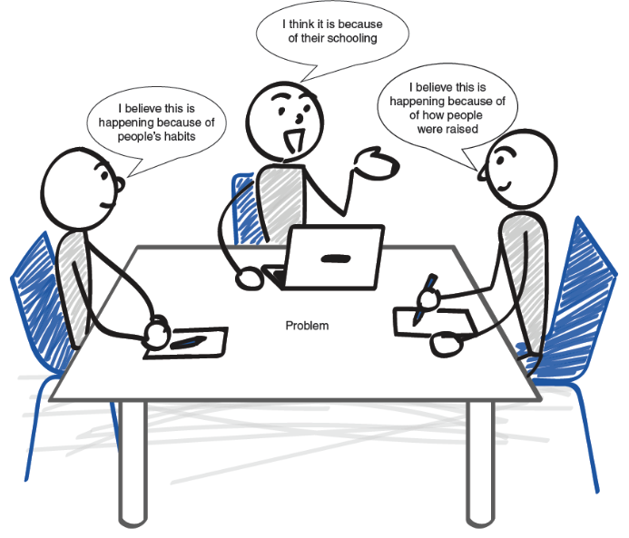

## Conceptualizing the Literature: Patterns

- Finding patterns in the literature is a simple and effective way to organize a literature review

# Thinking Critically

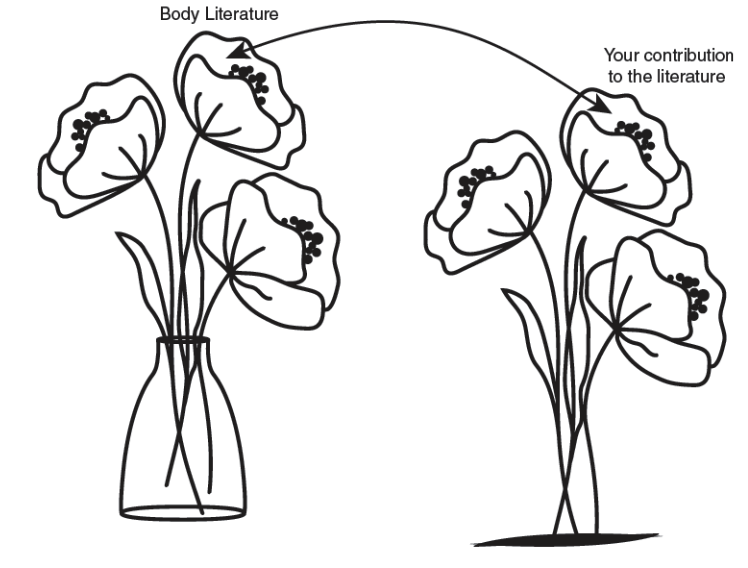

## Reading Critically

- Active reading, where one reads the information on the page while simultaneously considering the information given and coming up with additional ideas, leads to critical thinking.

## Analyzing Studies

- First look at the concepts, theories, and perspectives the researchers are using; ask questions regarding their intentions and if they considered other ideas.
- Next look closely at the methodologies employed

## Important questions to consider in each step of the review(Snyder, 2019).

- Phase 1: design
  - Is this review needed and what is the contribution of conducting this review?
  - What is the potential audience of this review?
  - What is the speci c purpose and research question(s) this review will be addressing?
  - What is an appropriate method to use of this review’s specific purpose?
  - What is the search strategy for this speci c review? (including search terms, databases, inclusion and exclusion criteria etc.)
- Phase 2: conduct
  - Does the search plan developed in phase one work to produce an appropriate sample or does it need adjustment?
  - What is the practical plan for selecting articles?
  - How will the search process and selection be documented?
  - How will the quality of the search process and selection be assessed?
- Phase 3: analysis
  - What type of information needs to be abstracted to fulfill the purpose of the specific review?
  - What type of information is needed to conduct the specific analysis?
  - How will reviewers be trained to ensure the quality of this process?
  - How will this process be documented and reported?
- Phase 4: structuring and writing the review
  - Are the motivation and the need for this review clearly communicated?
  - What standards of reporting are appropriate for this specific review?
  - What information needs to be included in the review?
  - Is the level of information provided enough and appropriate to allow for transparency so readers can judge the quality of the review?
  - The results clearly presented and explained?
  - Is the contribution of the review clearly communicated?

# Hypotheses or Research Questions

- Can end with either a research question or a hypothesis to make the argument that there are still unanswered questions worth investigating.
- A research question is broader while a hypothesis includes an understanding of the possible answer.

# Systematic Reviews of Literature

- Systematic review: is different from a literature review; it is a form of scientific study that brings together every study on a specific topic and draws conclusions from it.

## Systematic Reviews Versus Narrative Literature Reviews

- There are four major factors that make a systematic review different from a literature review:
  - the focus is different;
  - selection bias is reduced;
  - rigorous steps and procedures are followed, and
  - assessment and analyses of studies are involved.
- Selection bias: the researcher’s tendency to look closely at scientific work that aligns with their ideas and overlooks work that may oppose them.
- Methodology: how data are collected
- Meta-analyses: statistically recalculate the data from original studies based on standard criteria.

## 14 Types of ReviewGrant & Booth (2009)

- Critical review
- Literature review
- Mapping review/systematic map
- Meta-analysis
- Mixed studies review/mixed methods review
- Overview
- Qualitative systematic review / Qualitative evidence synthesis
- Rapid review
- Scoping review
- State-of-the-art review
- Systematic review
- Systematic search and review
- Systematized review
- Umbrella review